# Analyzing a billion NYC taxi trips in Spark

# Access your data

We analyze the full taxi data as described by [Todd Schneider](http://toddwschneider.com/posts/analyzing-1-1-billion-nyc-taxi-and-uber-trips-with-a-vengeance/) in using R and sparklyr. We load the billion record trips table into Apache Spark and then use sparklyr and dplyr to manipulate the data and run machine learning algorithms at scale.

The data represent 200 GB of uncompressed data in CSV format. When converted and compressed in the parquet format, the data are 70 GB. The data are stored in HDFS and pre-loaded in a Hive table.

The Hadoop cluster runs on Elastic Map Reduce (EMR) in AWS and has 12 worker nodes and one master node. The master node has R, RStudio Server Pro, and sparklyr loaded onto it.

## Connect to spark

Use sparklyr to create a new connection to Apache Spark.

```r
# Load libraries
library(sparklyr)
library(tidyverse)
library(shiny)
library(leaflet)
library(geosphere)
library(miniUI)
library(DT)
# Set environ vars
Sys.setenv(JAVA_HOME="/usr/lib/jvm/java-7-oracle-cloudera/")
Sys.setenv(SPARK_HOME = '/opt/cloudera/parcels/CDH/lib/spark')
# Configure cluster
conf <- spark_config()
conf$spark.executor.cores <- 16
conf$spark.executor.memory <- "26G"
conf$spark.yarn.am.cores  <- 16
conf$spark.yarn.am.memory <- "26G"
# Connect to cluster
sc <- spark_connect(master = "yarn-client", config = conf, version = '1.6.0')
```

## Prepare your data

```r
# Load lookup table
nyct2010_tbl <- spark_read_csv(sc, "nyct2010", "/user/nathan/nyct2010.csv")
# Create table references
trips_tbl <- tbl(sc, "trips_par")
# Join tables
trips_joined_tbl <- trips_tbl %>%
  filter(!is.na(pickup_nyct2010_gid) & !is.na(dropoff_nyct2010_gid)) %>%
  filter(cab_type_id %in% c(1, 2)) %>%
  mutate(cab_type = ifelse(cab_type_id == 1, "yellow", "green")) %>%
  mutate(pay_type = ifelse(
    lower(payment_type) %in% c('2', 'csh', 'cash', 'cas'), "cash", ifelse(
      lower(payment_type) %in% c('1', 'crd', 'credit', 'cre'), "credit", "unk"))) %>%
  mutate(other_amount = round(total_amount - fare_amount - tip_amount, 2)) %>%
  left_join(
    select(nyct2010_tbl, pickup_gid = gid,
           pickup_boro = boroname, pickup_nta = ntaname),
    by = c("pickup_nyct2010_gid" = "pickup_gid")) %>%
  left_join(
    select(nyct2010_tbl, dropoff_gid = gid,
           dropoff_boro = boroname, dropoff_nta = ntaname),
    by = c("dropoff_nyct2010_gid" = "dropoff_gid")) %>%
    select(pickup_datetime, pickup_latitude, pickup_longitude,
         pickup_nyct2010_gid, pickup_boro, pickup_nta,
         dropoff_datetime, dropoff_latitude, dropoff_longitude,
         dropoff_nyct2010_gid, dropoff_boro, dropoff_nta,
         cab_type, passenger_count, trip_distance,
         pay_type, fare_amount, tip_amount, other_amount, total_amount) %>%
  sdf_register("trips_par_joined")
# Cache table
system.time(tbl_cache(sc, "trips_model_data")) # 4.2 vs 4.3 vs 4.8 min
```

```
   user  system elapsed
  0.258   0.015 178.525
```

```r
trips_model_data_tbl <- tbl(sc, "trips_model_data")
```

# Understand your data

## Spark SQL and dplyr

Use dplyr syntax to write Spark SQL. When you’re ready to visualize your data, use `collect` to bring data into R memory. Notice the data describe roughly 170 million trips per year.

You can measure the time between pickup and dropoff for any two locations. In this example, we measure the time between JFK and mid-town. Notice the longest trip times occur around 4 PM.

```r
# Calculate total trips
trips_model_data_tbl %>% count
```

| n |
| --- |
| 1184591756 |

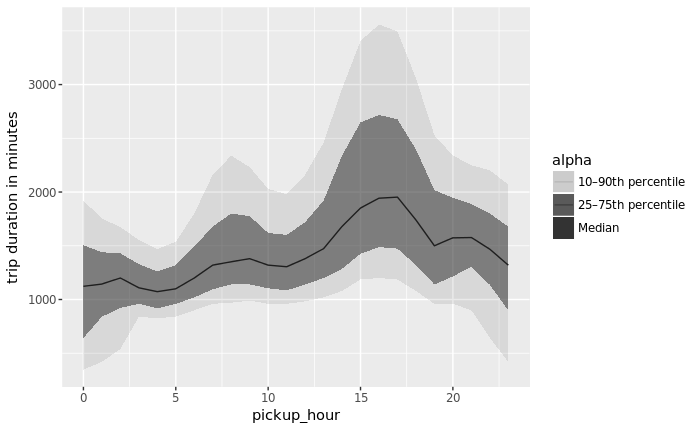

```r
# Calcluate trip time for a specific pickup and dropoff
pickup_dropoff_tbl <- trips_model_data_tbl %>%
  filter(pickup_nta == "Turtle Bay-East Midtown" & dropoff_nta == "Airport") %>%
  mutate(pickup_hour = hour(pickup_datetime)) %>%
  mutate(trip_time = unix_timestamp(dropoff_datetime) - unix_timestamp(pickup_datetime)) %>%
  group_by(pickup_hour) %>%
  summarize(n = n(),
            trip_time_mean = mean(trip_time),
            trip_time_p10 = percentile(trip_time, 0.10),
            trip_time_p25 = percentile(trip_time, 0.25),
            trip_time_p50 = percentile(trip_time, 0.50),
            trip_time_p75 = percentile(trip_time, 0.75),
            trip_time_p90 = percentile(trip_time, 0.90))
# Collect results
pickup_dropoff <- collect(pickup_dropoff_tbl)
# Plot
ggplot(pickup_dropoff, aes(x = pickup_hour)) +
          geom_line(aes(y = trip_time_p50, alpha = "Median")) +
          geom_ribbon(aes(ymin = trip_time_p25, ymax = trip_time_p75,
                          alpha = "25–75th percentile")) +
          geom_ribbon(aes(ymin = trip_time_p10, ymax = trip_time_p90,
                          alpha = "10–90th percentile")) +
          scale_y_continuous("trip duration in minutes")
```

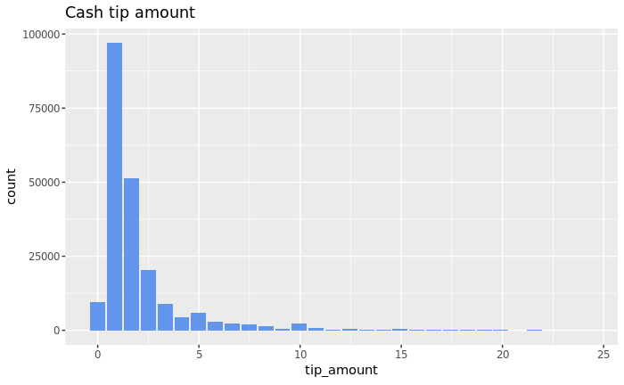

```r
# Visualization wrappers
source("sqlvis_histogram.R")
trips_model_data_tbl %>%
  filter(tip_amount > 0 & tip_amount < 25) %>%
  filter(pay_type == "cash") %>%
  sqlvis_compute_histogram("tip_amount") %>%
  sqlvis_ggplot_histogram(title = "Cash tip amount")
```

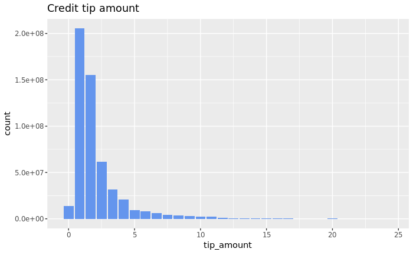

```r
trips_model_data_tbl %>%
  filter(tip_amount > 0 & tip_amount < 25) %>%
  filter(pay_type == "credit") %>%
  sqlvis_compute_histogram("tip_amount") %>%
  sqlvis_ggplot_histogram(title = "Credit tip amount")
```

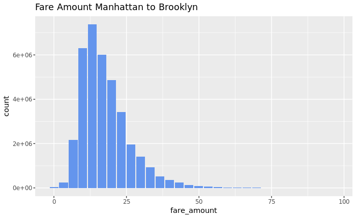

```r
# Fare amount Manhattan:Brooklyn
trips_model_data_tbl %>%
  filter(fare_amount > 0 & fare_amount < 100) %>%
  filter(pickup_boro == "Manhattan" & dropoff_boro == "Brooklyn") %>%
  sqlvis_compute_histogram("fare_amount") %>%
  sqlvis_ggplot_histogram(title = "Fare Amount Manhattan to Brooklyn")
```

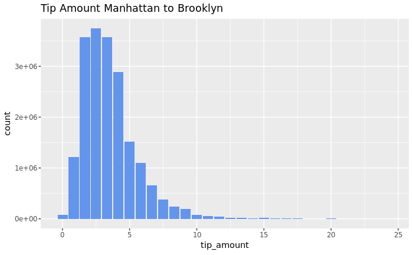

```r
# Tip amount Manhattan:Brooklyn
trips_model_data_tbl %>%
  filter(tip_amount > 0 & tip_amount < 25) %>%
  filter(pickup_boro == "Manhattan" & dropoff_boro == "Brooklyn") %>%
  sqlvis_compute_histogram("tip_amount") %>%
  sqlvis_ggplot_histogram(title = "Tip Amount Manhattan to Brooklyn")
```

Push your calculations into Spark even for visualizations. Collect only the information you need to create visualizations in ggplot2.

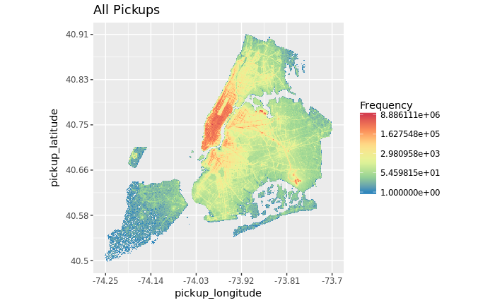

```r
source("sqlvis_raster.R")
trips_model_data_tbl %>%
  sqlvis_compute_tiles("pickup_longitude", "pickup_latitude", 300) %>%
  sqlvis_ggplot_raster(title = "All Pickups")
```

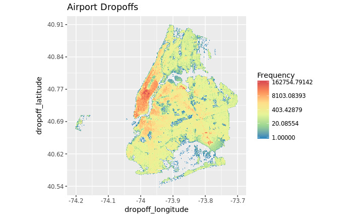

```r
trips_model_data_tbl %>%
  filter(pickup_nta == "Airport" & dropoff_boro != "Staten Island") %>%
  sqlvis_compute_tiles("dropoff_longitude", "dropoff_latitude", 300) %>%
  sqlvis_ggplot_raster(title = "Airport Dropoffs")
```

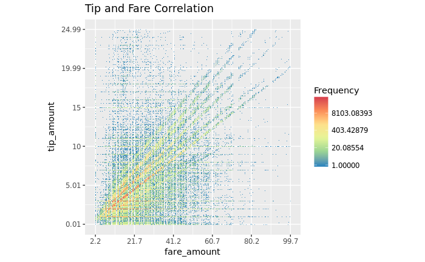

```r
trips_model_data_tbl %>%
  filter(fare_amount > 0 & fare_amount < 100) %>%
  filter(tip_amount > 0 & tip_amount < 25) %>%
  filter(pickup_boro == "Manhattan" & dropoff_boro == "Brooklyn") %>%
  sqlvis_compute_tiles("fare_amount", "tip_amount") %>%
  sqlvis_ggplot_raster(title = "Tip and Fare Correlation") -> p
p
```

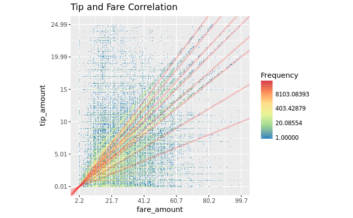

```r
p + geom_abline(intercept = 0,
                slope = c(10,15,20,22,25,27,30,33)/25,
                col = 'red', alpha = 0.2, size = 1)
```

### Facets

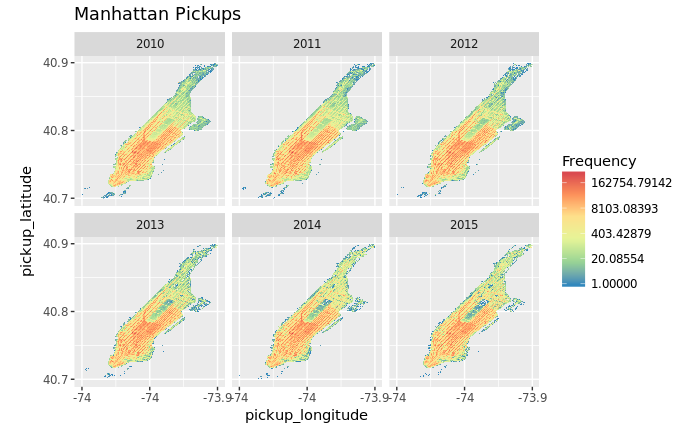

```r
trips_model_data_tbl %>%
  filter(pickup_boro == "Manhattan" & year(pickup_datetime) > 2009) %>%
  sqlvis_compute_tiles_g("pickup_longitude", "pickup_latitude", "year(pickup_datetime)", 300) %>%
  sqlvis_ggplot_raster_g(title = "Manhattan Pickups", ncol = 3)
```

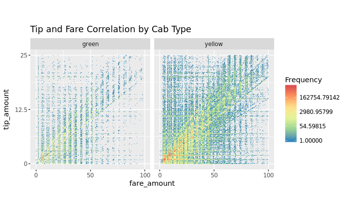

```r
trips_model_data_tbl %>%
  filter(fare_amount > 0 & fare_amount < 100) %>%
  filter(tip_amount > 0 & tip_amount < 25) %>%
  sqlvis_compute_tiles_g("fare_amount", "tip_amount", "cab_type") %>%
  sqlvis_ggplot_raster_g(title = "Tip and Fare Correlation by Cab Type", ncol = 2)
```

## HTML Widgets

Spark makes it easy to drill down to any level of you data. You can visualize the top dropoffs for any pickup location by entering your pickup location. In this example the pickup location is JFK International Airport.

```r
# Summarize trips from JFK Airport
jfk_pickup_tbl <- trips_model_data_tbl %>%
  filter(pickup_nta == "Airport") %>%
  filter(!is.na(dropoff_nyct2010_gid)) %>%
  mutate(trip_time = unix_timestamp(dropoff_datetime) - unix_timestamp(pickup_datetime)) %>%
  group_by(dropoff_nyct2010_gid) %>%
  summarize(n = n(),
            trip_time_mean = mean(trip_time),
            trip_dist_mean = mean(trip_distance),
            dropoff_latitude = mean(dropoff_latitude),
            dropoff_longitude = mean(dropoff_longitude),
            passenger_mean = mean(passenger_count),
            fare_amount = mean(fare_amount),
            tip_amount = mean(tip_amount))
# Collect top results
jfk_pickup <- jfk_pickup_tbl %>%
  mutate(n_rank = min_rank(desc(n))) %>%
  filter(n_rank <= 25) %>%
  collect
# Plot top trips on map
leaflet(jfk_pickup) %>%
  setView(lng = -73.9, lat = 40.7, zoom = 11) %>%
  addProviderTiles("CartoDB.Positron") %>%
  addCircleMarkers(~dropoff_longitude, ~dropoff_latitude, stroke = F, color = "red") %>%
  addCircleMarkers(-73.7781, 40.6413, fill = FALSE, color = "green")
```

[interactive chart not shown]

## Shiny Gadget

It is often useful to visualize the analyses interactively. Use a Shiny gadget to explore other pickup and dropoff locations.

```r
# Create list of geo groups to select from
geo_group <- nyct2010_tbl %>%
  distinct(ntaname) %>%
  arrange(ntaname) %>%
  collect

# Create the gadget user interface
ui <- miniPage(
  gadgetTitleBar("NYC Taxi Trips"),
  miniTabstripPanel(
    miniTabPanel("Inputs", icon = icon("sliders"),
                 miniContentPanel(
                   selectInput("pickup",  "Taxi Pickup", geo_group, "Lincoln Square"),
                   selectInput("dropoff",  "Taxi Dropoff", geo_group, "Upper West Side")
                   )
                 ),
    miniTabPanel("Plot", icon = icon("area-chart"),
                 miniContentPanel(
                   plotOutput("tripTimePlot")
                   )
    ),
    miniTabPanel("Map", icon = icon("map-o"),
                 miniContentPanel(
                   leafletOutput("tripLeaflet")
                 )
    ),
    miniTabPanel("Data", icon = icon("table"),
                 miniContentPanel(
                   dataTableOutput("table", height = "100%")
                 )
    )
  )
)

# Create the shiny gadget functions
server <- function(input, output) {

  shiny_pickup_dropoff_hour <- reactive({
    trips_model_data_tbl %>%
    filter(pickup_nta == input$pickup & dropoff_nta == input$dropoff) %>%
    mutate(pickup_hour = hour(pickup_datetime)) %>%
    mutate(trip_time = unix_timestamp(dropoff_datetime) - unix_timestamp(pickup_datetime)) %>%
    group_by(pickup_hour) %>%
    summarize(n = n(),
              pickup_latitude = mean(pickup_latitude),
              pickup_longitude = mean(pickup_longitude),
              dropoff_latitude = mean(dropoff_latitude),
              dropoff_longitude = mean(dropoff_longitude),
              trip_time_mean = mean(trip_time),
              trip_time_p10 = percentile(trip_time, 0.10),
              trip_time_p25 = percentile(trip_time, 0.25),
              trip_time_p50 = percentile(trip_time, 0.50),
              trip_time_p75 = percentile(trip_time, 0.75),
              trip_time_p90 = percentile(trip_time, 0.90)) %>%
    collect
  })

  shiny_pickup_dropoff <- reactive({
    shiny_pickup_dropoff_hour() %>%
      summarize(n = n(),
                pickup_latitude = mean(pickup_latitude),
                pickup_longitude = mean(pickup_longitude),
                dropoff_latitude = mean(dropoff_latitude),
                dropoff_longitude = mean(dropoff_longitude))
  })

  output$tripTimePlot <- renderPlot({
    ggplot(shiny_pickup_dropoff_hour(), aes(x = pickup_hour)) +
    geom_line(aes(y = trip_time_p50 / 60, alpha = "Median")) +
    geom_ribbon(aes(ymin = trip_time_p25 / 60,
                    ymax = trip_time_p75 / 60,
                    alpha = "25–75th percentile")) +
    geom_ribbon(aes(ymin = trip_time_p10 / 60,
                    ymax = trip_time_p90 / 60,
                    alpha = "10–90th percentile")) +
    scale_y_continuous("trip duration in minutes") +
    ggtitle("Trip time in minutes")
   })

  output$tripLeaflet <- renderLeaflet({
      leaflet(shiny_pickup_dropoff()) %>%
      addProviderTiles("CartoDB.Positron") %>%
      addCircleMarkers(~pickup_longitude, ~pickup_latitude, fill = FALSE, color = "green") %>%
      addCircleMarkers(~dropoff_longitude, ~dropoff_latitude, stroke = FALSE, color = "red")
  })

  output$table <- renderDataTable({
    shiny_pickup_dropoff_hour() %>%
      mutate(trip_time_mean = round(trip_time_mean / 60)) %>%
      mutate(trip_time_p50 = round(trip_time_p50 / 60)) %>%
      select(pickup_hour, n, trip_time_mean, trip_time_p50)
  })

  observeEvent(input$done, {
    stopApp(TRUE)
  })

}

# Run the gadget
runGadget(ui, server)
```

## Spark ML

With Spark ML you can run machine learning algorithms against all your data in Spark. Here we attempt to understand what factors influence tip amounts.

```r
# Select a model data set
model_tbl <- trips_model_data_tbl %>%
  filter(pickup_nta == "Turtle Bay-East Midtown" & dropoff_nta == "Airport") %>%
  #filter(!is.na(tip_amount)) %>%
  #filter(!is.na(fare_amount)) %>%
  #filter(!is.na(cab_type)) %>%
  #filter(!is.na(passenger_count)) %>%
  select(tip_amount, fare_amount, pay_type, cab_type, passenger_count)
# Partitioin into train and validate
model_partition_tbl <- model_tbl %>%
  sdf_partition(train = 0.2, test = 0.8, seed = 1234)
# Create table references
trips_train_tbl <- sdf_register(model_partition_tbl$train, "trips_train")
trips_test_tbl <- sdf_register(model_partition_tbl$train, "trips_test")
# Cache model data
system.time(tbl_cache(sc, "trips_train"))
```

```
   user  system elapsed
  0.024   0.000   5.796
```

```r
# Model data
model_formula <- formula(tip_amount ~
                           fare_amount + pay_type + cab_type + passenger_count)
m1 <- ml_linear_regression(trips_train_tbl, model_formula)
```

```
* No rows dropped by 'na.omit' call
```

```r
summary(m1)
```

```
Call: ml_linear_regression(trips_train_tbl, model_formula)

Deviance Residuals: (approximate):
     Min       1Q   Median       3Q      Max
-13.0614  -1.1860   0.2657   1.0051  93.9958

Coefficients:
                  Estimate Std. Error  t value  Pr(>|t|)
(Intercept)     -3.1551145  0.0132343 -238.405 < 2.2e-16 ***
fare_amount      0.0973411  0.0003274  297.319 < 2.2e-16 ***
pay_type_credit  7.0083876  0.0076647  914.375 < 2.2e-16 ***
pay_type_unk     1.6559930  0.0715310   23.151 < 2.2e-16 ***
passenger_count -0.0392428  0.0028324  -13.855 < 2.2e-16 ***
---
Signif. codes:  0 ‘***’ 0.001 ‘**’ 0.01 ‘*’ 0.05 ‘.’ 0.1 ‘ ’ 1

R-Squared: 0.6849
Root Mean Squared Error: 2.435
```